# Working Paper 5

# 1. Data Description

The Ministry of Education provides information regarding the salaries obtained by graduates and other related information at the website ”http://graduate.edu.ru”. A key purpose of this website is to provide accurate information to prospective university students and their families about the prospects of graduates from each of the universities or colleges. The Ministry of Finance collects information from all education establishments and others providing public service as a means to foster citizen engagement and accountability.This information includes details about revenue and income streams. This paper presents analysis from the merger of these two databases. The content of the data is presented in this section. Subsequent sections provide analysis and interpretation.

## 1.1. Graduate.edu portal

Graduate.edu allows the registered users to download all desirable information about the earnings of college or university graduates in .xlsx format. By using that service we obtained data about the number of graduates in 2013 in each university and college and their corresponding salaries in 2014, 2015 and 2016. Our final set of data consists of 1909 colleges, 423 universities, and 2975 pairs of university-study areas with information about the graduates earning in them. We filtered out universities and colleges with less than 100 and 50 graduates in 2013, respectively. Salaries in 2014 and 2015 were adjusted to the prices of 2016.

|  | Mean | Std | Quantile.25. | Quantile.50. | Quantile.75. |
| --- | --- | --- | --- | --- | --- |
| College Graduates Avg. Earnings 2014 | 301,255 | 81,712 | 247,093 | 279,156 | 328,995 |
| College Graduates Avg. Earnings 2015 | 281,567 | 76,821 | 229,697 | 261,667 | 311,208 |
| College Graduates Avg. Earnings 2016 | 287,918 | 80,574 | 233,763 | 267,480 | 320,583 |
| University Graduates Avg. Earnings 2014 | 411,050 | 152,936 | 300,829 | 365,771 | 481,628 |
| University Graduates Avg. Earnings 2015 | 419,488 | 158,256 | 304,798 | 368,518 | 496,961 |
| University Graduates Avg. Earnings 2016 | 433,387 | 175,586 | 305,856 | 380,304 | 508,152 |

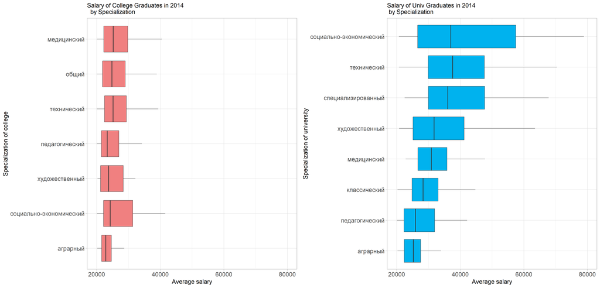

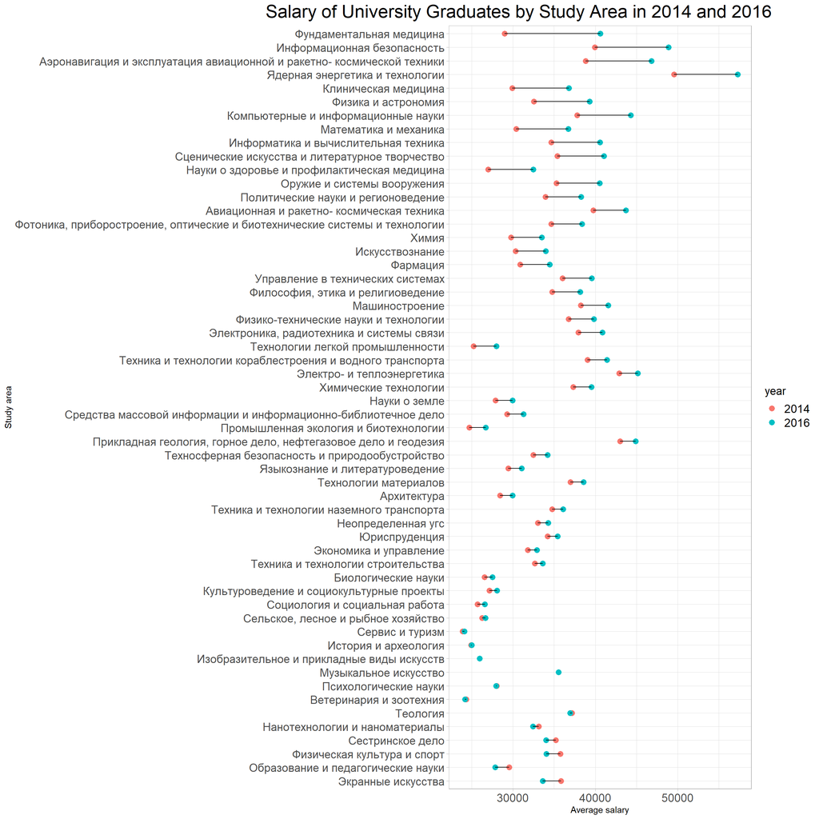

## 1.2. Bus.gov.ru portal

We obtained financial data about the colleges and universities from the open data section on the https://bus.gov.ru. It contains information about the total cash receipts of an organization for a given year and provides data on the income subcategories, such as cash receipts from paid services, target subsidy, budget investments, state (municipal) tasks. In our research, we approximated fee payments through the information about cash receipts from the paid services and used it together with the number of graduates for the calculation of the private education cost. To estimate the social cost of education we used total cash receipts in an organization

|  | Mean | Std | Quantile.25. | Quantile.50. | Quantile.75. |
| --- | --- | --- | --- | --- | --- |
| Number of College Graduates in 2013 | 192 | 149 | 97 | 154 | 243 |
| Total Cash Receipts in Colleges, mean 2012-2017 | 106,233,973 | 251,105,561 | 47,882,033 | 70,179,595 | 109,940,985 |
| Cash Receipts from the Paid Services in Colleges, mean 2012-2017 | 13,423,225 | 14,185,670 | 4,220,980 | 8,290,917 | 17,147,603 |
| Cash Receipts from the Target Subsidy in Colleges, mean 2012-2017 | 13,644,089 | 87,268,649 | 2,973,843 | 6,611,542 | 13,122,018 |
| Cash Receipts from the Budget Investments in Colleges, mean 2012-2017 | 380,156 | 2,290,744 | 0 | 0 | 0 |
| Cash Receipts from the State (Municipal) Tasks in Colleges, mean 2012-2017 | 71,886,730 | 89,598,370 | 34,835,450 | 51,403,288 | 77,701,603 |
| Social Cost for Colleges | 206,856 | 160,781 | 110,175 | 159,014 | 248,683 |
| Private Cost for Colleges | 24,287 | 20,441 | 10,204 | 18,962 | 32,854 |
| Number of University Graduates in 2013 | 1,673 | 1,547 | 649 | 1,242 | 2,094 |
| Total Cash Receipts in Universities, mean 2012-2017 | 1,557,966,861 | NA | 488,137,618 | 854,690,286 | 1,555,625,338 |
| Cash Receipts from the Paid Services in Universities, mean 2012-2017 | 553,941,067 | 677,845,294 | 133,154,544 | 296,913,560 | 663,924,931 |
| Cash Receipts from the Target Subsidy in Universities, mean 2012-2017 | 219,389,727 | 306,523,836 | 75,000,342 | 129,898,231 | 220,372,051 |
| Cash Receipts from the Budget Investments in Universities, mean 2012-2017 | 35,201,477 | 122,918,853 | 0 | 0 | 3,125,759 |
| Cash Receipts from the State (Municipal) Tasks in Universities, mean 2012-2017 | 653,606,278 | 1,060,196,583 | 246,276,440 | 362,030,015 | 649,967,746 |
| Social Cost for Universities | 264,869 | 265,986 | 107,278 | 176,603 | 308,393 |
| Private Cost for Universities | 97,452 | 119,749 | 34,450 | 60,034 | 112,030 |

# 2. Regional Returns

In the first part of our research, we focus on calculating the social and private regional internal rate of return by using the following methodology. We utilize the average wage in each age from 2014 to 2018 Rosstat Survey to calculate the potential earnings profiles and then add the mean social and private cost estimates for the regions to the begging of that profile. We also adjust for the foregone earnings of graduates by adding to the educational cost the potential wage that graduates missed due to the enrolment in the university of college, we took average wage in the region as the approximation of such earnings.

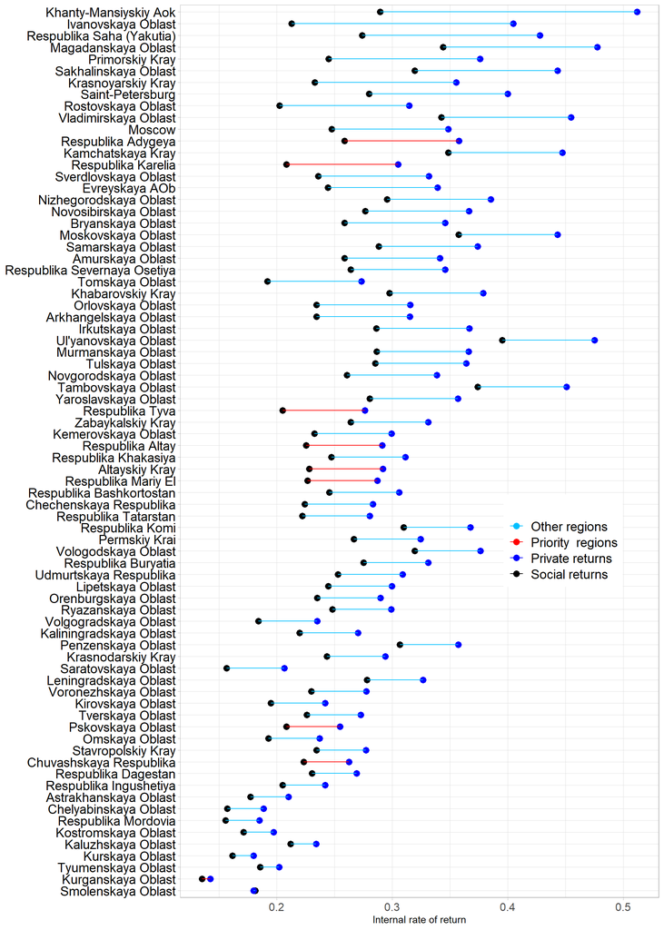

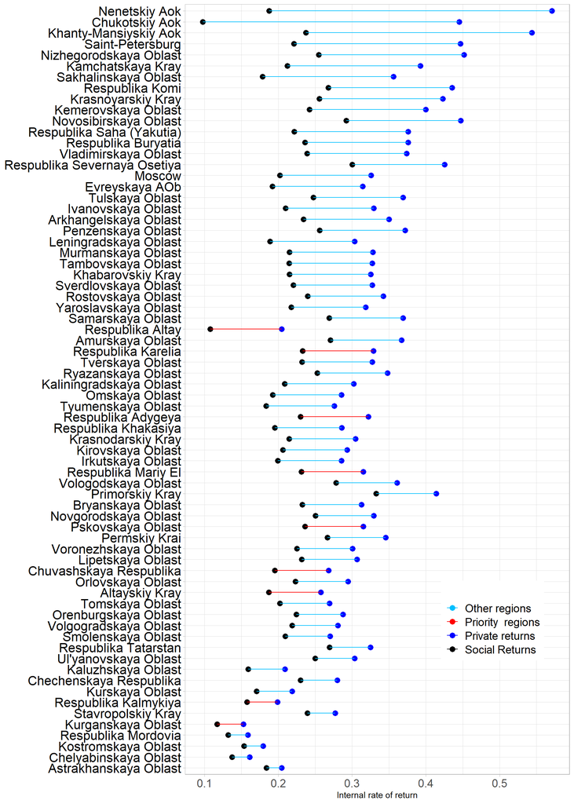

# 3. Organizational Returns

Data provided by graduate.edu allow us to calculate IRR directly for each educational organization. As in the previous part we use social and private cost as the cost part of the IRR specification, but now we utilize graduate salaries in 2014, 2015, and 2016 as the benefits obtained by the graduates. Resulting IRR estimations have a negative sign for most of the organizations since we have access only to the 3 years of observations after graduation. However such estimates still can be used to compare universities or colleges with each other.

Below, the tables with Top-10 and Bottom-10 universities/colleges ranked according to the social IRR.

| social returns | private returns | name | region | income | fee income | graduates number | salary 2014 | salary 2015 | salary 2016 |
| --- | --- | --- | --- | --- | --- | --- | --- | --- | --- |
| 0.07 | 0.09 | Бурятская государственная сельскохозяйственная академия имени В. Р. Филиппова | Республика Бурятия | 16419973 | 2135936 | 415 | 361213.896 | 360858.456 | 349404 |
| 0.05 | 0.09 | Российский государственный университет туризма и сервиса | Московская область | 1100392770 | 687722327 | 3019 | 500777.184 | 469830.564 | 477228 |
| 0.05 | 0.07 | Тюменский индустриальный университет | Тюменская область | 4183964503 | 3062237486 | 6655 | 891604.86 | 857896.704 | 891600 |
| 0.04 | 0.07 | Самарский государственный экономический университет | Самарская область | 772501080 | 617780376 | 1826 | 422044.608 | 425953.836 | 438048 |
| 0.04 | 0.2 | Северо-Восточный государственный университет | Магаданская область | 523571221 | 90276607 | 573 | 758097.924 | 772636.536 | 718128 |
| 0.04 | 0.1 | Сибирский государственный индустриальный университет | Кемеровская область | 541798925 | 207680607 | 1727 | 394167.576 | 390559.428 | 406224 |
| 0.04 | 0.13 | Самарский государственный технический университет | Самарская область | 2635986297 | 1474296345 | 2879 | 588119.28 | 601473.6 | 624144 |
| 0.03 | 0.09 | Сибирский государственный университет геосистем и технологий | Новосибирская область | 652983402 | 341877460 | 1768 | 364479.576 | 359817.444 | 358824 |
| 0.03 | 0.1 | Камчатский государственный технический университет | Камчатский край | 533540405 | 232659966 | 826 | 570974.46 | 681760.044 | 707748 |
| 0.02 | 0.15 | Арктический государственный институт культуры и искусств | Республика Саха (Якутия) | 221197434 | 45218603 | 366 | 477293.976 | 516393.36 | 527172 |
| … | … | … | … | … | … | … | … | … | … |
| -0.29 | -0.18 | Самарский государственный медицинский университет Минздрава России | Самарская область | 2808462605 | 1435110302 | 1169 | 304480.128 | 336323.988 | 332664 |
| -0.3 | -0.13 | Российский национальный исследовательский медицинский университет имени Н. И. Пирогова Минздрава России | Москва | 5036024164 | 1518805539 | 1165 | 476878.344 | 615520.836 | 650520 |
| -0.3 | -0.22 | Астраханский государственный архитектурно-строительный университет | Астраханская область | 325385006 | 68334706 | 282 | 304302 | 294747.768 | 304896 |
| -0.3 | -0.1 | Московская государственная художественно-промышленная академия им. С. Г. Строганова | Москва | 737231046 | 135743693 | 196 | 449416.944 | 683109.504 | 456420 |
| -0.3 | -0.17 | Сибирский государственный медицинский университет Минздрава России | Томская область | 2017650593 | 820981827 | 630 | 338235.384 | 409477.572 | 435996 |
| -0.31 | -0.16 | Брянский государственный аграрный университет | Брянская область | 692626466 | 187517317 | 408 | 247969.02 | 248377.752 | 257100 |
| -0.31 | -0.14 | Национальный исследовательский технологический университет «МИСиС» | Москва | 6407021047 | 1860200816 | 1394 | 571108.056 | 574587.216 | 615612 |
| -0.32 | -0.18 | Северо-Западный государственный медицинский университет имени И. И. Мечникова Минздрава России | Санкт-Петербург | 4976035086 | 2229931339 | 949 | 483691.74 | 529271.064 | 566856 |
| -0.34 | -0.16 | Саратовская государственная консерватория имени Л. В. Собинова | Саратовская область | 254287233 | 16350307 | 116 | 313980.288 | 313434.576 | 304608 |
| -0.35 | -0.15 | Уральский государственный аграрный университет | Свердловская область | 779596081 | 183471177 | 260 | 320125.704 | 307355.58 | 304932 |

| social returns | private returns | name | region | income | fee income | graduates number | salary 2014 | salary 2015 | salary 2016 |
| --- | --- | --- | --- | --- | --- | --- | --- | --- | --- |
| 0.07 | 0.09 | Бурятская государственная сельскохозяйственная академия имени В. Р. Филиппова | Республика Бурятия | 16419973 | 2135936 | 415 | 361213.896 | 360858.456 | 349404 |
| 0.05 | 0.09 | Российский государственный университет туризма и сервиса | Московская область | 1100392770 | 687722327 | 3019 | 500777.184 | 469830.564 | 477228 |
| 0.05 | 0.07 | Тюменский индустриальный университет | Тюменская область | 4183964503 | 3062237486 | 6655 | 891604.86 | 857896.704 | 891600 |
| 0.04 | 0.07 | Самарский государственный экономический университет | Самарская область | 772501080 | 617780376 | 1826 | 422044.608 | 425953.836 | 438048 |
| 0.04 | 0.2 | Северо-Восточный государственный университет | Магаданская область | 523571221 | 90276607 | 573 | 758097.924 | 772636.536 | 718128 |
| 0.04 | 0.1 | Сибирский государственный индустриальный университет | Кемеровская область | 541798925 | 207680607 | 1727 | 394167.576 | 390559.428 | 406224 |
| 0.04 | 0.13 | Самарский государственный технический университет | Самарская область | 2635986297 | 1474296345 | 2879 | 588119.28 | 601473.6 | 624144 |
| 0.03 | 0.09 | Сибирский государственный университет геосистем и технологий | Новосибирская область | 652983402 | 341877460 | 1768 | 364479.576 | 359817.444 | 358824 |
| 0.03 | 0.1 | Камчатский государственный технический университет | Камчатский край | 533540405 | 232659966 | 826 | 570974.46 | 681760.044 | 707748 |
| 0.02 | 0.15 | Арктический государственный институт культуры и искусств | Республика Саха (Якутия) | 221197434 | 45218603 | 366 | 477293.976 | 516393.36 | 527172 |

[output cut: 11 more lines]

| social returns | private returns | name | region | income | fee income | graduates number | salary 2014 | salary 2015 | salary 2016 |
| --- | --- | --- | --- | --- | --- | --- | --- | --- | --- |
| 0.13 | 0.35 | Самарский энергетический колледж | Самарская область | 77494648 | 15863750 | 140 | 539416.116 | 484520.4 | 508356 |
| 0.13 | 0.22 | Томский политехнический техникум | Томская область | 92245066 | 28143249 | 306 | 480500.28 | 479186.82 | 505800 |
| 0.12 | 0.24 | Новочеркасский геологоразведочный колледж | Ростовская область | 65409748 | 11559321 | 244 | 465314.868 | 379082.592 | 411528 |
| 0.12 | 0.28 | Вилюйский техникум | Республика Саха (Якутия) | 52924188 | 2300450 | 156 | 425013.408 | 426275.136 | 454404 |
| 0.11 | 0.21 | Киселевский горный техникум | Кемеровская область | 55748751 | 8735011 | 280 | 313505.28 | 352453.248 | 359652 |
| 0.11 | 0.25 | Высшая банковская школа | Санкт-Петербург | 63656896 | 6861353 | 229 | 410139.72 | 371384.244 | 397116 |
| 0.11 | 0.24 | Промышленно-технологический колледж | Санкт-Петербург | 71753379 | 1316861 | 305 | 367166.34 | 383850.684 | 352680 |
| 0.1 | 0.18 | Пермский нефтяной колледж | Пермский край | 64188098 | 31136275 | 171 | 502231.896 | 486949.428 | 515604 |
| 0.1 | 0.3 | Якутский автодорожный техникум | Республика Саха (Якутия) | 102647775 | 12136284 | 220 | 516749.328 | 425799.612 | 473868 |
| 0.1 | 0.19 | Сахалинский промышленно-экономический техникум | Сахалинская область | 170093710 | 53870817 | 489 | 510811.728 | 470498.868 | 487980 |
| … | … | … | … | … | … | … | … | … | … |
| -0.32 | -0.04 | Абаканский строительный техникум | Республика Хакасия | 102510593 | 2504406 | 70 | 230779.668 | 246167.208 | 229092 |
| -0.32 | -0.24 | Ичалковский педагогический колледж | Республика Мордовия | 40375002 | 2698852 | 62 | 246083.832 | 236284.02 | 216048 |
| -0.32 | -0.19 | Озерский технический колледж | Челябинская область | 217475527 | 23639667 | 154 | 277849.992 | 311082.66 | 325056 |
| -0.32 | 0.04 | Колледж метростроя | Санкт-Петербург | 121820668 | 11148350 | 55 | 304109.028 | 278926.956 | 286884 |
| -0.32 | -0.16 | Калужский технический колледж | Калужская область | 210753603 | 12964108 | 154 | 305801.244 | 275302.692 | 263820 |
| -0.33 | -0.02 | Емельяновский дорожно-строительный техникум | Красноярский край | 126101858 | 15068464 | 73 | 259428.588 | 238507.416 | 219576 |
| -0.33 | -0.14 | Технологический колледж № 21 | Москва | 382506424 | 44584864 | 216 | 303114.48 | 286252.596 | 307524 |
| -0.33 | 0.12 | Сахалинский техникум механизации сельского хозяйства | Сахалинская область | 295523466 | 14124141 | 82 | 484255.812 | 400686.804 | 422424 |
| -0.34 | 0.15 | Колледж «Красносельский» | Санкт-Петербург | 183183432 | 752462 | 74 | 296865.156 | 316866.06 | 277284 |
| -0.34 | -0.02 | Краснодарский педагогический колледж | Краснодарский край | 264550658 | 6833323 | 148 | 284707.92 | 239625.54 | 226572 |

| social returns | private returns | name | region | income | fee income | graduates number | salary 2014 | salary 2015 | salary 2016 |
| --- | --- | --- | --- | --- | --- | --- | --- | --- | --- |
| 0.13 | 0.35 | Самарский энергетический колледж | Самарская область | 77494648 | 15863750 | 140 | 539416.116 | 484520.4 | 508356 |
| 0.13 | 0.22 | Томский политехнический техникум | Томская область | 92245066 | 28143249 | 306 | 480500.28 | 479186.82 | 505800 |
| 0.12 | 0.24 | Новочеркасский геологоразведочный колледж | Ростовская область | 65409748 | 11559321 | 244 | 465314.868 | 379082.592 | 411528 |
| 0.12 | 0.28 | Вилюйский техникум | Республика Саха (Якутия) | 52924188 | 2300450 | 156 | 425013.408 | 426275.136 | 454404 |
| 0.11 | 0.21 | Киселевский горный техникум | Кемеровская область | 55748751 | 8735011 | 280 | 313505.28 | 352453.248 | 359652 |
| 0.11 | 0.25 | Высшая банковская школа | Санкт-Петербург | 63656896 | 6861353 | 229 | 410139.72 | 371384.244 | 397116 |
| 0.11 | 0.24 | Промышленно-технологический колледж | Санкт-Петербург | 71753379 | 1316861 | 305 | 367166.34 | 383850.684 | 352680 |
| 0.1 | 0.18 | Пермский нефтяной колледж | Пермский край | 64188098 | 31136275 | 171 | 502231.896 | 486949.428 | 515604 |
| 0.1 | 0.3 | Якутский автодорожный техникум | Республика Саха (Якутия) | 102647775 | 12136284 | 220 | 516749.328 | 425799.612 | 473868 |
| 0.1 | 0.19 | Сахалинский промышленно-экономический техникум | Сахалинская область | 170093710 | 53870817 | 489 | 510811.728 | 470498.868 | 487980 |

[output cut: 11 more lines]

The provided data allow us to map the educational organizations according to their precise coordinates. We can observe a few examples of such plotting for Moscow universities and Saint Peterburg colleges with an indication of the level of social returns for each organization.

[output not shown]

[figure not shown]

[figure not shown]

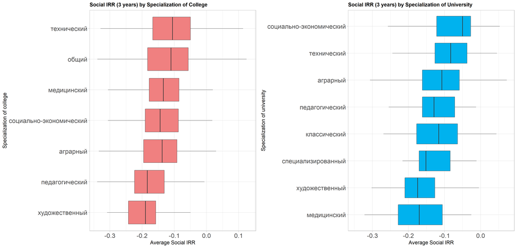

[figure not shown]

We estimate the factors which are explaining the difference in returns between organization by conducting 4 separate linear regression models with 1) Social IRR in colleges, 2) Private IRR in colleges, 3) Social IRR in universities, and 4) Private IRR in universities as dependent variables. We are going to use 1) the specialization of organization, 2) the number of graduates, 3) the number of staff, 4) the average wage in the organization, 5) the proportion of income obtained from paid services and 6) the average wage in the region as the main predictors for these models.

Tables with Linear Regression estimates for the Social/Private returns of Higher/Vocational education are depicted below.

[output not shown]

Colleges with higher graduates are tend to provide higher social returns, while the average wage in the organization boosts only private returns.

[output not shown]